# STAT 147 | HW

Week 4 HW

Victoria Nguyen

# **Instructions**

The goal of this assignment is to continue our exploration with plots, hypothesis testing, and linear regression. Please use the RMD file `FIRST_LAST_HW_04.Rmd` to answer your questions. Delete code or answer chunks as necessary. You will submit both the RMD file and the corresponding HTML file from the knitted document.

Note: you may need to search the internet to find answers for some of the questions.

You will be graded as follows:

- Does your R chunks run (some errors are acceptable in this assignment)?
- Have you completed the assignment in its entirety?
- Have you followed the instructions carefully?
- Have you responded to the questions correctly?

#### Grading

- **(20 pts)** Have you completed the assignment in its entirety?
- **(20 pts)** Are your responses correct for the subset of randomly graded questions?
- **(5 pts)** CODE DOCUMENTATION. Add comments to nearly every line explaining what the line of code is doing.
- **(5 pts)** Submitted Knitted Document

# Questions

## Part 1

### Q1

#### Part A

Is to be completed in Lab 4A. Below is a description of what is necessary from the lab.

- The merged data set.

#### Part B

##### 1. Load the data set df3.csv and merge it to the previous data set

##### 2. Using the newly merged data set, create a scatter plot and fit a trend line to the data. Is there a positive or negative association with the data?

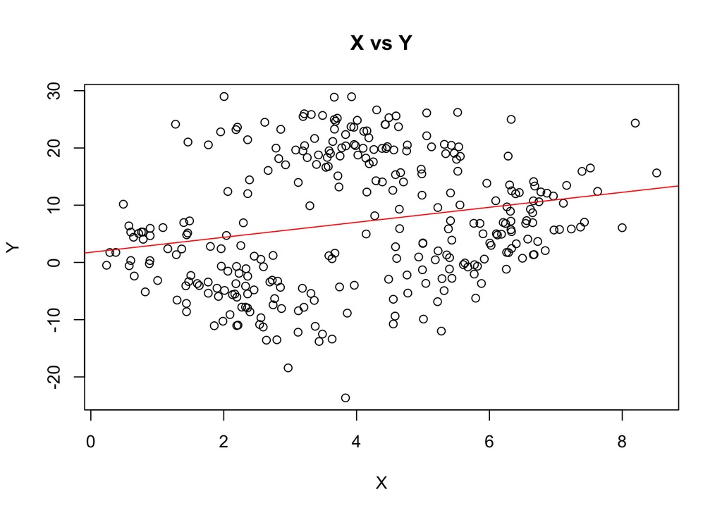

there is a slightly positive association with the data

##### 3. Using the newly merged data set, create a scatter plot and fit a trend line for each group. What is the association for each group?

```
## <list_of<
##   tbl_df<
##     id   : integer
##     x    : double
##     y    : double
##     group: integer
##   >
## >[3]>
## [[1]]
## # A tibble: 100 x 4
##       id     x       y group
##    <int> <dbl>   <dbl> <int>
##  1     3 1.30   -6.58      1
##  2    11 3.12  -12.2       1
##  3    12 3.31   -5.42      1
##  4    17 0.893   4.67      1
##  5    18 2.46    1.09      1
##  6    20 1.44   -7.16      1
##  7    27 0.719   5.06      1
##  8    29 0.237  -0.495     1
##  9    35 1.92   -5.93      1
## 10    38 0.880  -0.224     1
## # … with 90 more rows
##
## [[2]]
## # A tibble: 100 x 4
##       id     x     y group
##    <int> <dbl> <dbl> <int>
##  1     1  3.84 20.4      2
##  2     2  4.29 14.3      2
##  3     4  3.32 25.8      2
##  4    10  2.93 17.1      2
##  5    13  5.54 20.2      2
##  6    14  4.46 20.2      2
##  7    16  5.47 19.1      2
##  8    21  4.98 15.5      2
##  9    22  4.16 12.3      2
## 10    23  3.30  9.90     2
## # … with 90 more rows
##
## [[3]]
## # A tibble: 100 x 4
##       id     x       y group
##    <int> <dbl>   <dbl> <int>
##  1     5  5.96  13.8       3
##  2     6  6.33   2.43      3
##  3     7  4.14   4.97      3
##  4     8  5.56  10.0       3
##  5     9  5.68  -0.796     3
##  6    15  6.67   1.38      3
##  7    19  5.86   6.82      3
##  8    24  5.22   9.59      3
##  9    25  7.52  16.5       3
## 10    26  5.28 -12.0       3
## # … with 90 more rows
```

```
##
## Call:
## lm(formula = y ~ x, data = df_merge1)
##
## Coefficients:
## (Intercept)            x
##       5.197       -4.198
```

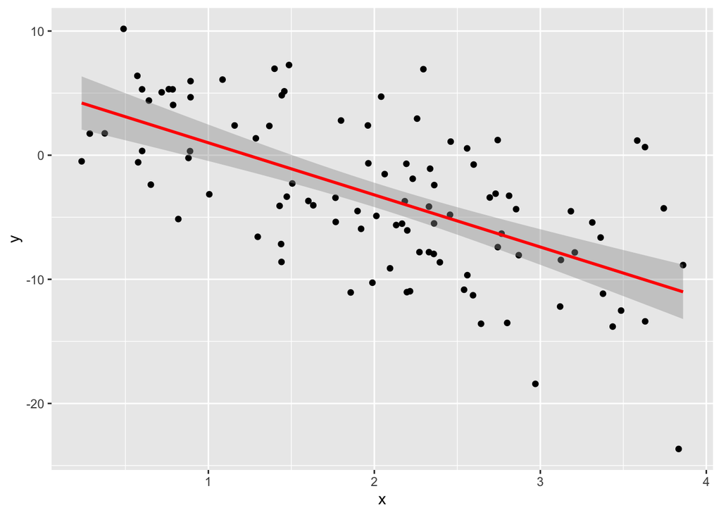

```
##
## Call:
## lm(formula = y ~ x, data = df_merge2)
##
## Coefficients:
## (Intercept)            x
##     21.6505      -0.4546
```

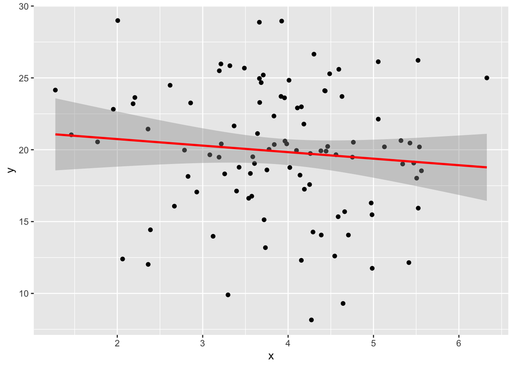

```
##
## Call:
## lm(formula = y ~ x, data = df_merge3)
##
## Coefficients:
## (Intercept)            x
##     -24.289        4.775
```

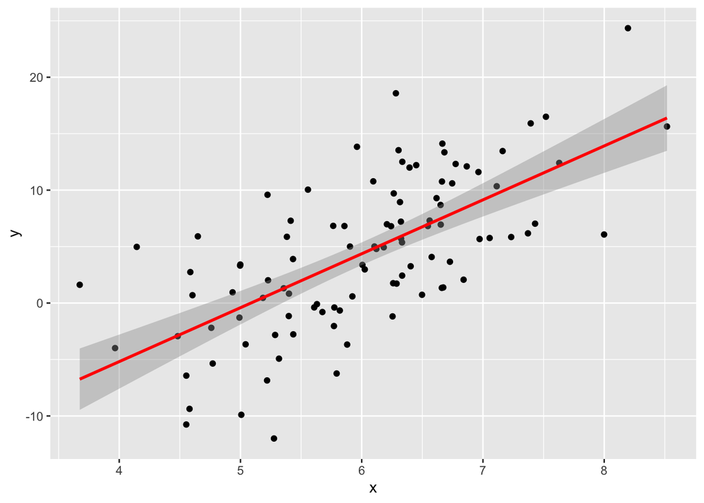

Group 1: negative Group 2: negative Group 3: positive

##### 4. For each group, fit a linear regression model and interpret the slope for each group. The units for x and y are liters.

```
##
## Call:
## lm(formula = y ~ x, data = df_merge1)
##
## Coefficients:
## (Intercept)            x
##       5.197       -4.198
```

```
##
## Call:
## lm(formula = y ~ x, data = df_merge2)
##
## Coefficients:
## (Intercept)            x
##     21.6505      -0.4546
```

```
##
## Call:
## lm(formula = y ~ x, data = df_merge3)
##
## Coefficients:
## (Intercept)            x
##     -24.289        4.775
```

Equations: Group 1: y = -4.198x + 5.197 Group 2: y = -0.4546x + 21.6505 Group 3: y = 4.7755x - 24.2894

## Part 2

### Q2

#### Part A

Is to be completed in Lab 4B. Below is a description of what is necessary from the lab.

- The 2-sample independent t-test results.
- The `dreams` data.

#### Part B

##### 1. Conduct a paired t-test on the dreams data using the variables extra and group. Is there a significant difference between the groups? You can assume the vectors are ordered correctly.

```
##    extra group
## 1    0.7     1
## 2   -1.6     1
## 3   -0.2     1
## 4   -1.2     1
## 5   -0.1     1
## 6    3.4     1
## 7    3.7     1
## 8    0.8     1
## 9    0.0     1
## 10   2.0     1
## 11   1.9     2
## 12   0.8     2
## 13   1.1     2
## 14   0.1     2
## 15  -0.1     2
## 16   4.4     2
## 17   5.5     2
## 18   1.6     2
## 19   4.6     2
## 20   3.4     2
```

```
## # A tibble: 2 x 4
##   group count  mean    sd
##   <fct> <int> <dbl> <dbl>
## 1 1        10  0.75  1.79
## 2 2        10  2.33  2.00
```

```
##      extra        group
##  Min.   :-1.600   1:10
##  1st Qu.:-0.175   2: 0
##  Median : 0.350
##  Mean   : 0.750
##  3rd Qu.: 1.700
##  Max.   : 3.700
```

```
##      extra        group
##  Min.   :-0.100   1: 0
##  1st Qu.: 0.875   2:10
##  Median : 1.750
##  Mean   : 2.330
##  3rd Qu.: 4.150
##  Max.   : 5.500
```

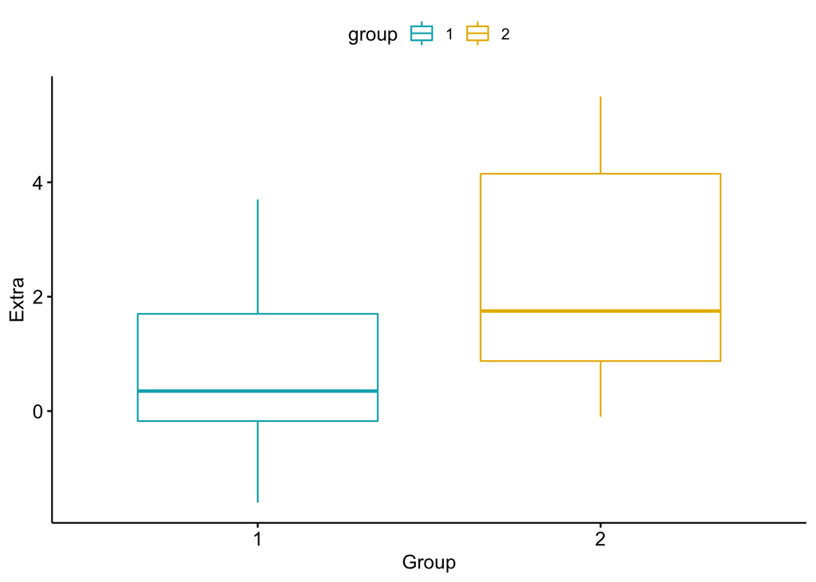

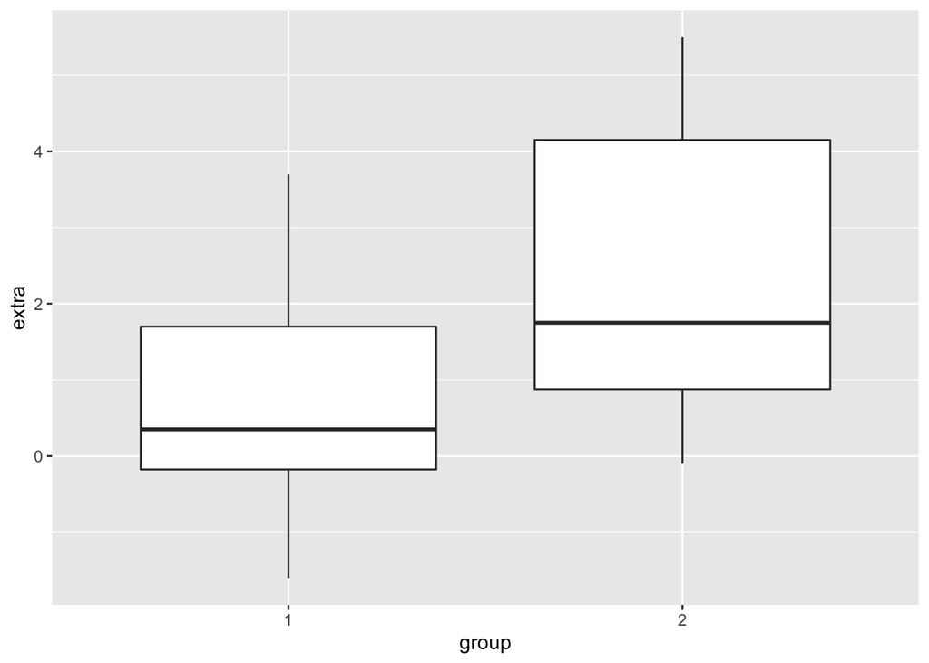

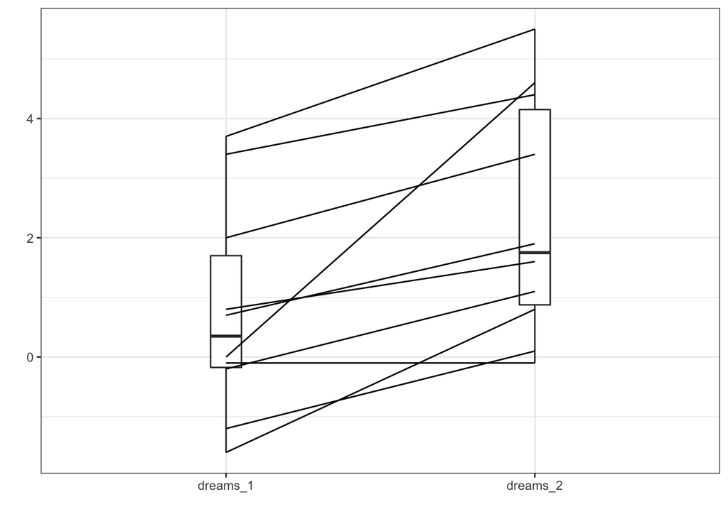

```
##
##  Paired t-test
##
## data:  dreams_1 and dreams_2
## t = -4.0621, df = 9, p-value = 0.002833
## alternative hypothesis: true difference in means is not equal to 0
## 95 percent confidence interval:
##  -2.4598858 -0.7001142
## sample estimates:
## mean of the differences
##                   -1.58
```

Yes, there is a significant difference between the groups.

##### 2. Compare the results from the paired t-test and the 2-sample independent t-test. Are the results the same?

```
##
##  Two Sample t-test
##
## data:  dreams_1 and dreams_2
## t = -1.8608, df = 18, p-value = 0.07919
## alternative hypothesis: true difference in means is not equal to 0
## 95 percent confidence interval:
##  -3.363874  0.203874
## sample estimates:
## mean of x mean of y
##      0.75      2.33
```

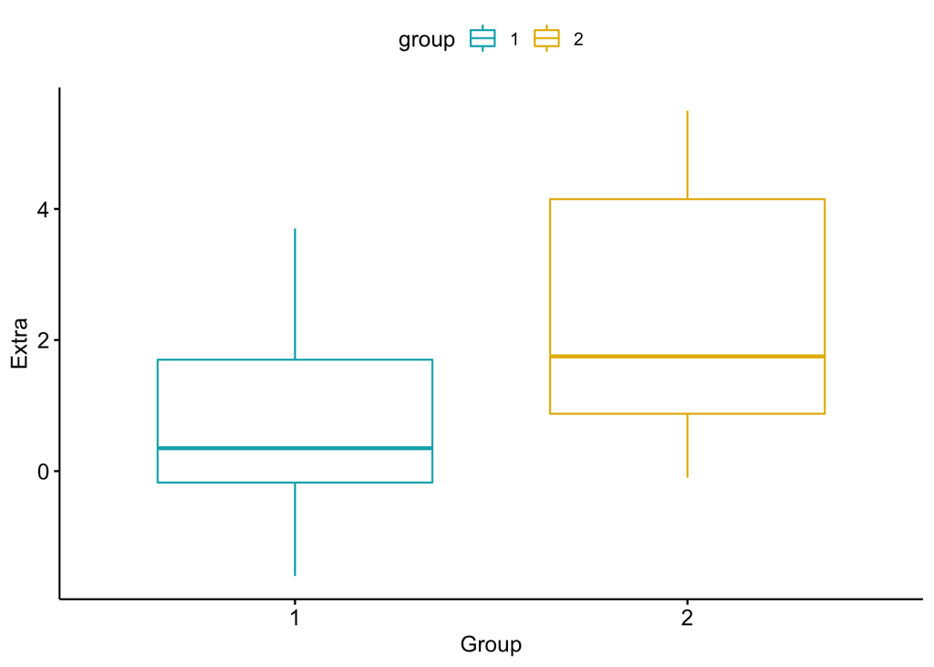

```
##
##  Paired t-test
##
## data:  dreams_1 and dreams_2
## t = -4.0621, df = 9, p-value = 0.002833
## alternative hypothesis: true difference in means is not equal to 0
## 95 percent confidence interval:
##  -2.4598858 -0.7001142
## sample estimates:
## mean of the differences
##                   -1.58
```

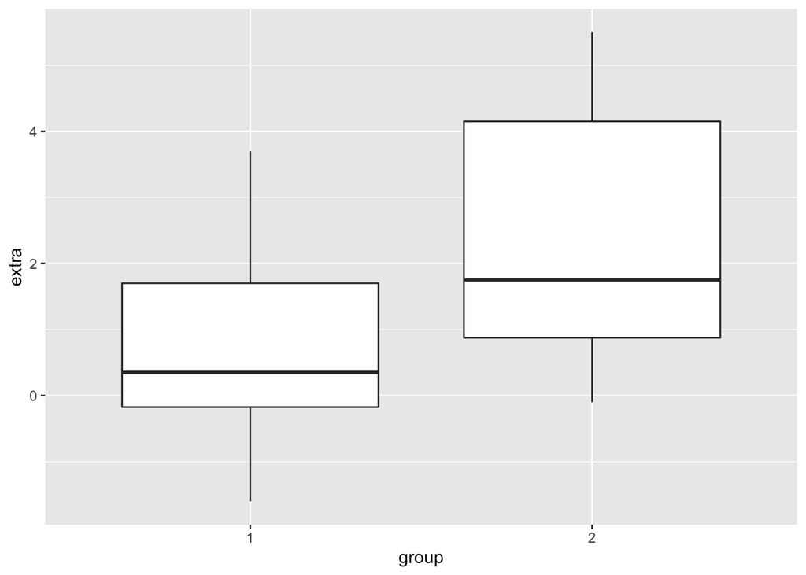

##### 3. The dreams data was constructed from the sleep data in R. Read the help documentation for the sleep data. Determine if the data is independent or dependent?

```
## [1] "sleep"
```

```
##    extra group
## 1    0.7     1
## 2   -1.6     1
## 3   -0.2     1
## 4   -1.2     1
## 5   -0.1     1
## 6    3.4     1
## 7    3.7     1
## 8    0.8     1
## 9    0.0     1
## 10   2.0     1
## 11   1.9     2
## 12   0.8     2
## 13   1.1     2
## 14   0.1     2
## 15  -0.1     2
## 16   4.4     2
## 17   5.5     2
## 18   1.6     2
## 19   4.6     2
## 20   3.4     2
```

```
##    ID extra.x group.x extra.y group.y
## 1   1     0.7       1     1.9       2
## 2  10     2.0       1     3.4       2
## 3   2    -1.6       1     0.8       2
## 4   3    -0.2       1     1.1       2
## 5   4    -1.2       1     0.1       2
## 6   5    -0.1       1    -0.1       2
## 7   6     3.4       1     4.4       2
## 8   7     3.7       1     5.5       2
## 9   8     0.8       1     1.6       2
## 10  9     0.0       1     4.6       2
```

```
##    ID extra.x extra.y
## 1   1     0.7     1.9
## 2  10     2.0     3.4
## 3   2    -1.6     0.8
## 4   3    -0.2     1.1
## 5   4    -1.2     0.1
## 6   5    -0.1    -0.1
## 7   6     3.4     4.4
## 8   7     3.7     5.5
## 9   8     0.8     1.6
## 10  9     0.0     4.6
```

```
##
##  Pearson's Chi-squared test
##
## data:  sleep_new2$extra.x and sleep_new2$extra.y
## X-squared = 90, df = 81, p-value = 0.2313
```

```
## [1] 0.2313417
```

p-value = 0.2313417 The two are not dependent.

##### 4.Look at the confidence intervals for both tests. Which is larger? Postulate why one is larger than the other?

```
## [1] -3.567748
```

```
## [1] -1.759772
```

Confidence intervals: (-3.363874, 0.203874) & (-2.4598858, -0.7001142) The two-sample t-test has a larger confidence interval that’s approximately twice as large as the paired t-test. This is because, for the paired test, the data is condensed as we put the data into matched pairs, making the data set itself less wide.

An increase in sample size typically results in a higher confidence interval, which we saw here proportionally.

## Part 3

### Q3 The faithful data set in R provides information on waiting time (waiting, independent) and duration of eruption (eruptions, dependent) about the Old Faithful geyser in Yellow Stone National Park. Fit a Linear regression model and interpret the slope term.

```
##     eruptions waiting
## 1       3.600      79
## 2       1.800      54
## 3       3.333      74
## 4       2.283      62
## 5       4.533      85
## 6       2.883      55
## 7       4.700      88
## 8       3.600      85
## 9       1.950      51
## 10      4.350      85
## 11      1.833      54
## 12      3.917      84
## 13      4.200      78
## 14      1.750      47
```

[output cut: 258 more lines]

```
##
## Call:
## lm(formula = eruptions ~ waiting, data = faithful)
##
## Residuals:
##      Min       1Q   Median       3Q      Max
## -1.29917 -0.37689  0.03508  0.34909  1.19329
##
## Coefficients:
##              Estimate Std. Error t value Pr(>|t|)
## (Intercept) -1.874016   0.160143  -11.70   <2e-16 ***
## waiting      0.075628   0.002219   34.09   <2e-16 ***
## ---
## Signif. codes:  0 '***' 0.001 '**' 0.01 '*' 0.05 '.' 0.1 ' ' 1
##
## Residual standard error: 0.4965 on 270 degrees of freedom
## Multiple R-squared:  0.8115, Adjusted R-squared:  0.8108
## F-statistic:  1162 on 1 and 270 DF,  p-value: < 2.2e-16
```

Equation: Eruptions = 0.075628(waiting) -1.874016

The slope shows that there is a small increase in eruption time in relation to waiting time.

### Q4 The beaver1 data set in R provide temperature data for a beaver at different time points. Create time-series plot (line plot) showing the temperature trend of the beaver.

```
##   day time  temp activ
## 1 346  840 36.33     0
## 2 346  850 36.34     0
## 3 346  900 36.35     0
## 4 346  910 36.42     0
## 5 346  920 36.55     0
## 6 346  930 36.69     0
```

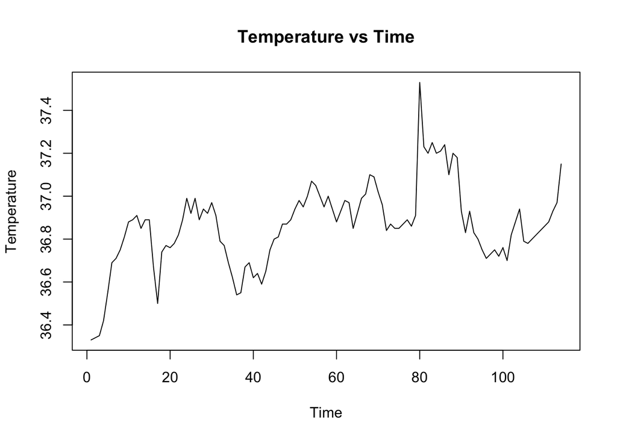

### Q5 The trees data set in R provides measurements of the diameter (Girth, independent) and height(Height, dependent) of 31 fallen black cherry trees. Fit a linear regression model between the 2 variable and interpret the slope term.

```
##    Girth Height Volume
## 1    8.3     70   10.3
## 2    8.6     65   10.3
## 3    8.8     63   10.2
## 4   10.5     72   16.4
## 5   10.7     81   18.8
## 6   10.8     83   19.7
## 7   11.0     66   15.6
## 8   11.0     75   18.2
## 9   11.1     80   22.6
## 10  11.2     75   19.9
## 11  11.3     79   24.2
## 12  11.4     76   21.0
## 13  11.4     76   21.4
## 14  11.7     69   21.3
```

[output cut: 17 more lines]

```
## [1] 0.5192801
```

```
##
## Call:
## lm(formula = height ~ girth, data = trees)
##
## Residuals:
##      Min       1Q   Median       3Q      Max
## -12.5816  -2.7686   0.3163   2.4728   9.9456
##
## Coefficients:
##             Estimate Std. Error t value Pr(>|t|)
## (Intercept)  62.0313     4.3833  14.152 1.49e-14 ***
## girth         1.0544     0.3222   3.272  0.00276 **
## ---
## Signif. codes:  0 '***' 0.001 '**' 0.01 '*' 0.05 '.' 0.1 ' ' 1
##
## Residual standard error: 5.538 on 29 degrees of freedom
## Multiple R-squared:  0.2697, Adjusted R-squared:  0.2445
## F-statistic: 10.71 on 1 and 29 DF,  p-value: 0.002758
```

The linear regression model for the height and girth of trees is: height = 1.0544(girth) + 62.0313

The slope (1.054) shows that height does not increase much with girth (1:1.054 ratio)

### Q6 The rock data set in R provides measurements of different rock samples in the petroleum reservoir. Run a correlation test between the variables area and shape.

```
##     area     peri     shape   perm
## 1   4990 2791.900 0.0903296    6.3
## 2   7002 3892.600 0.1486220    6.3
## 3   7558 3930.660 0.1833120    6.3
## 4   7352 3869.320 0.1170630    6.3
## 5   7943 3948.540 0.1224170   17.1
## 6   7979 4010.150 0.1670450   17.1
## 7   9333 4345.750 0.1896510   17.1
## 8   8209 4344.750 0.1641270   17.1
## 9   8393 3682.040 0.2036540  119.0
## 10  6425 3098.650 0.1623940  119.0
## 11  9364 4480.050 0.1509440  119.0
## 12  8624 3986.240 0.1481410  119.0
## 13 10651 4036.540 0.2285950   82.4
## 14  8868 3518.040 0.2316230   82.4
```

[output cut: 34 more lines]

```
## [1] -0.1821611
```

```
##
##  Pearson's product-moment correlation
##
## data:  rock$area and rock$shape
## t = -1.2565, df = 46, p-value = 0.2153
## alternative hypothesis: true correlation is not equal to 0
## 95 percent confidence interval:
##  -0.4433488  0.1075396
## sample estimates:
##        cor
## -0.1821611
```

### Q7 The gehan data set in the R package MASS provides clinical trials on remission times for Leukemia patients. Conduct a hypothesis test comparing the treatment and control group (treat) on remission times time. Interpret the results.

```
##    pair time cens   treat
## 1     1    1    1 control
## 2     1   10    1    6-MP
## 3     2   22    1 control
## 4     2    7    1    6-MP
## 5     3    3    1 control
## 6     3   32    0    6-MP
## 7     4   12    1 control
## 8     4   23    1    6-MP
## 9     5    8    1 control
## 10    5   22    1    6-MP
## 11    6   17    1 control
## 12    6    6    1    6-MP
## 13    7    2    1 control
## 14    7   16    1    6-MP
```

[output cut: 28 more lines]

```
##
##  Welch Two Sample t-test
##
## data:  gehan_control$time and gehan_treatment$time
## t = -3.2433, df = 34.242, p-value = 0.002637
## alternative hypothesis: true difference in means is not equal to 0
## 95 percent confidence interval:
##  -13.708497  -3.148646
## sample estimates:
## mean of x mean of y
##  8.666667 17.095238
```

Because the p-value is less than .05, we reject the null hypothesis.

## Part 4

### Q8 Watch the following video: https://www.youtube.com/watch?v=Q2dewZweAtU(https://www.youtube.com/watch?v=Q2dewZweAtU). What is optimization?

Optimization is the selection of inputs that result in the best outputs. This typically involves finding the minimum amount of inputs that maximizes (or minimizes) outputs while also being given constraints on the inputs.

### Q9 If simple linear regression is used when the outcome is normally distributed, what type of regression is used when the outcome follows a Poisson distribution?

Poisson regression is used when the outcome follows a Poisson distribution.

### Q10 Using ggplot2, what is the function you need to plot a map?

Using ggplot2: ggplot(map_data_name) + geom_sf() + coord_sf()

Can be used to plot a map.